# STATS 769 Lab 03

## The data

The data are trips on electric scooters and bikes in Austin, Texas. The data came in the form of eleven CSV files, one per month (form April 2018 to February 2019). Each file contains 5000 trips.

## Linux processing

The following shell code counts the number of bicycle trips in each CSV file. We loop through each CSV file, use `grep` to find lines that contain the word “bicycle” and pipe the result to `wc` to count the number of such lines.

```bash
for i in /course/Labs/Lab02/trips*.csv
do
    echo $i
    grep bicycle $i | wc -l
done
```

```
/course/Labs/Lab02/trips-2018-10.csv
163
/course/Labs/Lab02/trips-2018-11.csv
265
/course/Labs/Lab02/trips-2018-12.csv
81
/course/Labs/Lab02/trips-2018-4.csv
1
/course/Labs/Lab02/trips-2018-5.csv
0
/course/Labs/Lab02/trips-2018-6.csv
0
/course/Labs/Lab02/trips-2018-7.csv
257
/course/Labs/Lab02/trips-2018-8.csv
158
/course/Labs/Lab02/trips-2018-9.csv
164
/course/Labs/Lab02/trips-2019-1.csv
144
/course/Labs/Lab02/trips-2019-2.csv
160
```

An alternative solution that I saw somebody doing in the lab, which is much nicer:

```bash
grep -c bicycle /course/Labs/Lab02/trips*.csv
```

```
/course/Labs/Lab02/trips-2018-10.csv:163
/course/Labs/Lab02/trips-2018-11.csv:265
/course/Labs/Lab02/trips-2018-12.csv:81
/course/Labs/Lab02/trips-2018-4.csv:1
/course/Labs/Lab02/trips-2018-5.csv:0
/course/Labs/Lab02/trips-2018-6.csv:0
/course/Labs/Lab02/trips-2018-7.csv:257
/course/Labs/Lab02/trips-2018-8.csv:158
/course/Labs/Lab02/trips-2018-9.csv:164
/course/Labs/Lab02/trips-2019-1.csv:144
/course/Labs/Lab02/trips-2019-2.csv:160
```

The next shell code extracts just the scooter trips from each CSV file. Again, we loop through the CSV files, use `basename` to get the CSV file name without its path, use `head` to pull the first row (column names) off the CSV and redirect the result to a new CSV file prefixed with “scooter-”. Then we use `grep` to extract the lines containing the word “scooter” and append those to the “scooter-” file.

```bash
for i in /course/Labs/Lab02/trips*.csv
do
    file=$(basename $i)
    head -1 $i > scooter-$file
    grep scooter $i >> scooter-$file
done
```

## R processing

The following code reads the scooter CSV files into R and combines them to create a single data frame.

```r
years <- rep(2018:2019, c(9, 2))
months <- c(4:12, 1:2)
filenames <- paste0("scooter-trips-", years, "-", months, ".csv")
trips <- do.call(rbind, lapply(filenames, read.csv))
```

We exclude non-positive durations and distances and log both variables.

```r
modelTrips <- subset(trips,
                     Trip.Duration > 0 & Trip.Distance > 0)
tripDuration <- log(modelTrips$Trip.Duration)
tripDistance <- log(modelTrips$Trip.Distance)
```

## K-fold cross-validation

The following code repeats the sequence 1 to 10 until the result is as long as the number of trips. We then sample that repeated sequence to get a randomised set of labels where the number of times each label occurs is as equal as possible.

```r
## Define 10 splits
labels <- rep(1:10, length.out=nrow(modelTrips))
groups <- sample(labels)
```

The `mse()` function splits the data into test and training sets using a label between 1 and 10. It then uses the training set to fit a model relating trip duration to trip distance based on the provided formula, generates predictions for the test set, and calculates the Mean Square Error for the test set.

```r
mse <- function(i, formula) {
    testSet <- groups == i
    trainSet <- groups != i
    fit <- lm(formula,
              data.frame(x=tripDistance[trainSet], y=tripDuration[trainSet]))
    pred <- predict(fit, data.frame(x=tripDistance[testSet]))
    mean((pred - tripDuration[testSet])^2)
}
```

## Choosing a model

The following code evaluates a simple linear regression model using the formula `y ~ x`. We perform cross-validation by calling `mse()` for i from 1 to 10, then average the resulting MSE values.

```r
mean(sapply(1:10, mse, y ~ x))
```

```
[1] 0.3833567
```

The following code evaluates a polynomial regression model by cross-validation using the formula `y ~ x + I(x^2)`.

```r
mean(sapply(1:10, mse, y ~ x + I(x^2)))
```

```
[1] 0.3077596
```

The MSE is lower if we add a squared term to the linear model.

## The final model

We fit both models to the full data and produce a plot to show the predictions of both models against the raw data. This confirms that the polynomial regression model captures the trend in the data better than the simple linear regression model, although the predictions increasing again at very small distances is a bit of a concern.

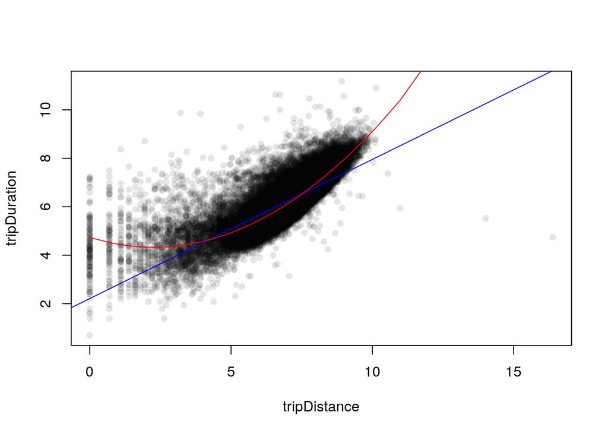

```r
lmFit <- lm(y ~ x, data.frame(x=tripDistance, y=tripDuration))
polyFit <- lm(y ~ x + I(x^2), data.frame(x=tripDistance, y=tripDuration))
polyPred <- predict(polyFit)
plot(tripDistance, tripDuration, pch=16, col=rgb(0,0,0,.1))
abline(lmFit, col="blue")
lines(sort(tripDistance), polyPred[order(tripDistance)], col="red")
```

## The Makefile

The Makefile below generates an HTML file from the R Markdown file when we type `make` (because there is only one targe) and does nothing if the HTML file is newer than the R Markdown file (because the Rmd file is a dependency of the HTML file target).

```
lab03-model.html: lab03-model.Rmd
    Rscript -e 'rmarkdown::render("lab03-model.Rmd")'
```

## Conclusion

We used k-fold cross-validation (k = 10) to measure test error for both a simple linear regression of trip duration on trip distance and a polynomial regression that added a squared trip distance term. The polynomial regression performed better (produced a lower test error).

A plot of the two models shows that the non-linear polynomial model matches the pattern in the data better, although the prediction of an increase in trip duration as trip distance *decreases* (for very short trips) might be questioned.

The final report was generated on Linux using a Makefile, which allowed us to process the R Markdown file to an HTML file by simply typing `make`.